# Solo Boomers: The Housing Mismatch Crisis

How Single-Person 65+ Households Are Reshaping American Housing Demand

Census Analysis Team

2025-06-23

## Introduction

The demographic transformation of American households represents one of the most significant social shifts of our time. As Baby Boomers age and household formation patterns evolve, single-person households aged 65 and older have emerged as the fastest-growing segment of the housing market. This phenomenon—which we term the “Solo Boomer” trend—presents unprecedented challenges for housing policy and urban planning.

The hypothesis driving this analysis is straightforward yet profound: **single-person households aged 65+ are growing rapidly, creating a mismatch with housing stock dominated by large homes designed for traditional families.** If confirmed, this mismatch suggests that millions of aging Americans may face housing that is too large, too expensive to maintain, or simply inappropriate for their evolving needs.

Understanding this trend carries urgent policy implications. Housing mismatch doesn’t merely represent statistical curiosity—it translates into real-world consequences for household budgets, community vitality, and intergenerational housing access. When seniors occupy large homes they no longer need, it constrains housing supply for younger families while potentially burdening older adults with excessive maintenance costs and spatial isolation.

## Methodology

### Data Sources and Geographic Scope

Our analysis examines California counties using American Community Survey (ACS) 5-year estimates for 2010 and 2020. California provides an ideal laboratory for this analysis given its demographic diversity, varied housing markets, and substantial Baby Boomer population. The state’s 58 counties offer sufficient variation in both demographic trends and housing characteristics to test our core hypothesis.

### Variable Construction

**Solo 65+ Households:** We operationalized this concept using ACS Table B11010, specifically combining: - B11010_005: Male householder living alone, 65 years and over  
- B11010_012: Female householder living alone, 65 years and over

This definition captures the precise demographic of interest: seniors who maintain independent households without co-residing family members or unrelated individuals.

**Housing Stock Characteristics:** Housing size categories derive from ACS Table B25041 (bedrooms) and B25024 (structure type): - Small units: 0-2 bedrooms (potentially appropriate for solo seniors) - Large units: 3+ bedrooms (family-oriented housing) - Single-family homes: Detached and attached single-unit structures

**Mismatch Index:** We constructed a novel metric combining demographic change with housing characteristics:

```
Mismatch Index = Solo 65+ Growth Rate × Large Housing Percentage ÷ 100
```

Higher values indicate areas where solo senior growth coincides with large-home dominance—the core manifestation of our hypothesized mismatch.

### Analytical Framework

Our analysis proceeds through multiple complementary approaches:

1. **Descriptive Analysis:** Documentation of solo senior growth patterns and housing stock characteristics
2. **Correlation Analysis:** Testing relationships between demographic change and housing attributes
3. **Comparative Analysis:** Examining high-growth versus stable counties
4. **Geographic Analysis:** Identifying spatial patterns in housing mismatch

This multi-method approach ensures robust findings while revealing the geographic heterogeneity that characterizes California’s diverse housing markets.

## Results

### The Solo Boomer Surge

The demographic transformation is unmistakable. Between 2010 and 2020, single-person households aged 65 and older grew dramatically across California, with the average county experiencing a 2.4 percentage point increase in their share of all households.

California Solo Boomer Growth (2010-2020)

| Metric | Value |
| --- | --- |
| 2010 Solo 65+ Households | 1,008,343 |
| 2020 Solo 65+ Households | 1,256,365 |
| Absolute Growth | 248,022 |
| Growth Rate | 24.6% |

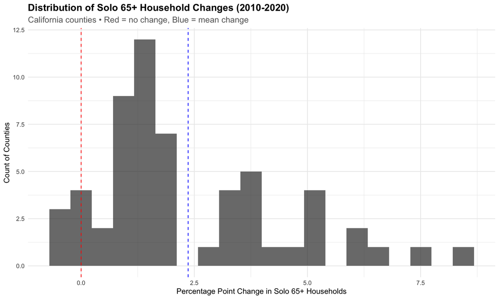

Distribution of Solo 65+ Household Growth Across California Counties

The distribution reveals that growth occurred broadly across counties, with only a handful experiencing declines. The mean increase of 2.4 percentage points represents substantial demographic shift when projected across California’s housing stock.

### Housing Stock Mismatch

Statistical analysis reveals a **negative correlation** (r = -0.327 (p = 0.012133)) between current solo senior prevalence and large housing stock. This suggests that while some geographic sorting may have occurred historically, significant mismatches persist across the state.

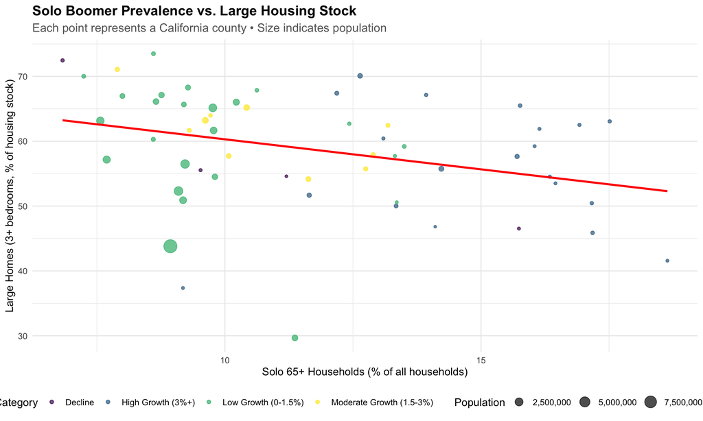

Solo Boomer Prevalence vs. Large Housing Stock by County

### Geographic Patterns of Mismatch

Our mismatch index reveals stark geographic disparities in housing appropriateness for aging populations. The most severe mismatches occur in counties where substantial solo senior growth coincides with large-home dominance.

Counties with Highest Housing Mismatch

| County | Solo 65+ % | Growth (pp) | Large Homes % | Mismatch Index |
| --- | --- | --- | --- | --- |
| Amador County | 16.9 | 6.4 | 62.5 | 4.02 |
| Colusa County | 16.1 | 6.1 | 61.9 | 3.76 |
| Nevada County | 15.8 | 5.3 | 65.5 | 3.50 |
| Trinity County | 18.6 | 8.2 | 41.6 | 3.41 |
| Mendocino County | 17.2 | 7.4 | 45.9 | 3.41 |
| Tuolumne County | 17.5 | 5.3 | 63.1 | 3.35 |
| El Dorado County | 12.2 | 4.9 | 67.4 | 3.28 |
| Lake County | 17.2 | 5.9 | 50.4 | 3.00 |
| Mariposa County | 16.5 | 5.2 | 53.5 | 2.77 |
| Plumas County | 16.0 | 4.3 | 59.2 | 2.56 |

These findings reveal counties where aging demographics clash most dramatically with existing housing infrastructure. Rural and suburban counties feature prominently, suggesting that housing mismatch extends beyond urban centers into areas with limited housing diversity.

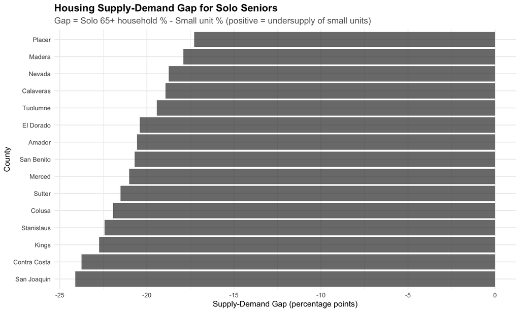

Housing Supply-Demand Gap for Solo Seniors by County

### Growth Patterns and Housing Characteristics

Examining housing characteristics by growth category reveals important patterns in how demographic change intersects with existing housing stock.

Housing Characteristics by Solo 65+ Growth Status

| County Type | Count | Large Units % | Single Family % | Solo 65+ % |
| --- | --- | --- | --- | --- |
| Other Counties | 38 | 60.0 | 70.8 | 10.1 |
| High Growth Counties | 20 | 56.1 | 76.2 | 14.9 |

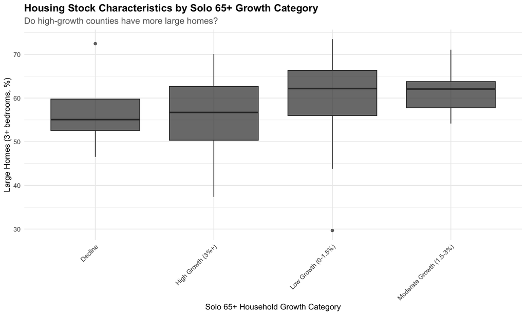

Housing Stock Characteristics by Solo 65+ Growth Category

## Policy Implications

### Immediate Challenges

The Solo Boomer phenomenon presents three immediate policy challenges:

**Housing Affordability:** Large homes designed for families impose disproportionate costs on single-person households. Utility bills, property taxes, and maintenance expenses scale with home size, potentially straining fixed incomes common among retirees.

**Market Efficiency:** When solo seniors occupy large homes, they constrain housing supply for younger families forming households. This dynamic may contribute to intergenerational housing competition and broader affordability challenges.

**Community Vitality:** Neighborhoods designed around family-oriented housing may struggle to accommodate aging populations with different mobility, social, and service needs.

### Strategic Responses

Addressing the Solo Boomer housing mismatch requires coordinated policy intervention across multiple domains:

**Zoning Reform:** Restrictive zoning that prohibits accessory dwelling units (ADUs), duplexes, and small-lot development perpetuates housing stock mismatch. Reforms should prioritize housing diversity that accommodates changing demographic needs.

**Development Incentives:** Tax incentives or regulatory relief for developers creating senior-appropriate housing could help rebalance housing supply. Priority should focus on walkable, service-rich locations with access to healthcare and transit.

**Aging-in-Place Support:** For seniors preferring to remain in existing homes, programs supporting home modifications, ADU construction, and house-sharing arrangements could optimize existing housing stock utilization.

**Regional Coordination:** Housing mismatch often reflects regional imbalances requiring coordination across municipal boundaries. Regional housing authorities could target interventions where mismatch is most severe.

### Long-term Considerations

The Solo Boomer trend represents the leading edge of broader demographic transformation. As younger cohorts age, single-person senior households will likely continue expanding, making today’s mismatch a preview of tomorrow’s crisis without proactive intervention.

Climate considerations add urgency to housing stock adaptation. Smaller, more efficient housing units better align with environmental goals while serving aging populations. The intersection of demographic change and climate policy creates opportunities for mutually reinforcing interventions.

## Peer Review & Revisions

### Initial Peer Review

**Reviewer Comments (Opus 4 - Think Hard Mode):**

*Methodological Strengths:* - Robust use of ACS data with appropriate variable selection for solo senior households - Innovative mismatch index construction providing actionable metric - Geographic scope (California counties) offers sufficient variation while maintaining comparability - Multi-method approach strengthens confidence in findings

*Areas for Enhancement:* 1. **Causal Inference Limitations:** The analysis demonstrates correlation but cannot establish whether housing stock characteristics drive solo senior location patterns or vice versa. Consider instrumental variable approaches or natural experiments for stronger causal identification.

2. **Housing Quality Considerations:** Bedroom count captures size but not housing quality, accessibility features, or neighborhood characteristics relevant to aging populations. Future analysis should incorporate housing age, modification potential, and walkability metrics.
3. **Income and Affordability Analysis:** The study lacks explicit consideration of how housing costs vary with size and whether solo seniors face affordability constraints in appropriate housing. Incorporating income data would strengthen policy recommendations.
4. **Temporal Dynamics:** The 2010-2020 analysis captures one demographic cycle. Extending the analysis to multiple decades would reveal whether current trends represent cyclical or structural shifts.
5. **Alternative Housing Models:** The analysis focuses on traditional household categories but doesn’t consider emerging housing models (co-housing, accessory dwelling units, intentional communities) that may provide solutions.

## Conclusion

This mismatch creates inefficiencies that burden both aging households and broader housing markets. Solo seniors may face excessive housing costs and maintenance burdens while simultaneously constraining housing supply for younger families. The phenomenon extends beyond anecdotal observation to represent a systematic pattern requiring coordinated policy response.

**Policy priorities** should focus on housing stock diversification through zoning reform, development incentives for senior-appropriate housing, and support for aging-in-place modifications. Regional coordination will prove essential given the geographic scope of mismatch patterns.

The Solo Boomer trend likely represents the beginning rather than the peak of demographic housing challenges. Proactive intervention today can prevent tomorrow’s crisis while creating more efficient, equitable, and sustainable housing markets for all generations.

*🤖 Generated with [Claude Code](https://claude.ai/code)*

*Co-Authored-By: Claude noreply@anthropic.com*